# HELPrct (Data Verbs) Activity

Mohil Patel

March 2, 2022

## Set Up:

```r
# load packages
library(tidyverse)  # for data verbs like `group-by()` & `summarise()`
library(mosaicData) # includes `HELPrct` data set
library(mosaic)     # includes `mplot()` interactive plot builder
library(esquisse)   # includes `esquisser()` interactive plot builder


# Load the HELPrct data from `mosaicData` into our RStudio environment
data("HELPrct", package = "mosaicData")
```

## Data Description

```r
glimpse(HELPrct)
```

```
Rows: 453
Columns: 30
$ age              <int> 37, 37, 26, 39, 32, 47, 49, 28, 50, 39, 34, 58, 58, 60, 36, 28, 35, 29, 27, 27, 41, 3~
$ anysubstatus     <int> 1, 1, 1, 1, 1, 1, NA, 1, 1, 1, NA, 0, 1, 1, 1, 1, 1, 0, 0, 1, NA, 1, NA, 1, 1, 1, 1, ~
$ anysub           <fct> yes, yes, yes, yes, yes, yes, NA, yes, yes, yes, NA, no, yes, yes, yes, yes, yes, no,~
$ cesd             <int> 49, 30, 39, 15, 39, 6, 52, 32, 50, 46, 46, 49, 22, 36, 43, 35, 19, 40, 52, 37, 35, 18~
$ d1               <int> 3, 22, 0, 2, 12, 1, 14, 1, 14, 4, 0, 3, 5, 10, 2, 6, 1, 2, 0, 1, 1, 1, 4, 2, 4, 1, 0,~
$ daysanysub       <int> 177, 2, 3, 189, 2, 31, NA, 47, 31, 115, NA, 192, 6, 6, 0, 27, 2, 220, 198, 52, NA, 12~
$ dayslink         <int> 225, NA, 365, 343, 57, 365, 334, 365, 365, 382, 365, 365, 365, 22, 443, 41, 405, 449,~
$ drugrisk         <int> 0, 0, 20, 0, 0, 0, 0, 7, 18, 20, 8, 0, 0, 0, 0, 0, 0, 0, 10, 0, 12, 0, 0, 0, 0, 0, 1,~
$ e2b              <int> NA, NA, NA, 1, 1, NA, 1, 8, 7, 3, NA, NA, NA, 1, NA, 2, NA, 1, 4, NA, 1, NA, 2, 3, NA~
$ female           <int> 0, 0, 0, 1, 0, 1, 1, 0, 1, 0, 1, 1, 0, 0, 0, 1, 0, 0, 1, 0, 0, 0, 0, 0, 1, 0, 0, 0, 0~
$ sex              <fct> male, male, male, female, male, female, female, male, female, male, female, female, m~
$ g1b              <fct> yes, yes, no, no, no, no, yes, yes, no, no, no, no, no, no, no, yes, no, yes, yes, no~
$ homeless         <fct> housed, homeless, housed, housed, homeless, housed, housed, homeless, homeless, homel~
```

[output cut: 17 more lines]

*TASK 1: Write a couple of sentences describing the `HELPrct` data–What is the setting for the data? What are they about?*

The data is looking at individuals who have struggled with drug abuse. A case is a person who struggles with drug abuse. The variables help describe each individuals drug abuse situation as well as their life situation

## Basic Summaries with `summarise()`

*TASK 2: Produce an expression involving `summarize()` and `HELPrct` that will produce the following.*

1. *number of people (cases) in `HELPrct` study*
2. *combined total number of times in the past 6 months all the people in `HELPrct` entered a detox program (measured at baseline)*
3. *mean time (in days) to first use of any substance post-detox for all the people in `HELPrct`*

```r
HELPrct %>%
  summarise( total_people = n(),total_detox= sum(e2b,na.rm=TRUE),use_mean = mean(daysanysub,na.rm=TRUE) )
```

| total_people | total_detox | use_mean |
| --- | --- | --- |
| 453 | 536 | 75.30738 |

```r
NA
```

```r
HELPrct %>%
  summarise( use_mean = mean(daysanysub,na.rm=TRUE) )
```

| use_mean |
| --- |
| 75.30738 |

```r
NA
NA
```

## Subgrouping with `group_by()`

*TASK 3: Repeat task 2 above, but calculate the results group-by-group. Show your code and write a sentence or two about what you observe in the results for each of the following:*

1. *males versus females*

```r
HELPrct %>%
  group_by(female)%>%
  summarise( total_people = n(),total_detox= sum(e2b,na.rm=TRUE),use_mean = mean(daysanysub,na.rm=TRUE) )
```

| female | total_people | total_detox | use_mean |
| --- | --- | --- | --- |
| 0 | 346 | 447 | 72.72727 |
| 1 | 107 | 89 | 83.77193 |

2. *homeless or not*

```r
HELPrct %>%
  group_by(homeless)%>%
  summarise( total_people = n(),total_detox= sum(e2b,na.rm=TRUE),use_mean = mean(daysanysub,na.rm=TRUE) )
```

| homeless | total_people | total_detox | use_mean |
| --- | --- | --- | --- |
| homeless | 209 | 379 | 74.33051 |
| housed | 244 | 157 | 76.22222 |

3. *substance*

```r
HELPrct %>%
  group_by(substance)%>%
  summarise( total_people = n(),total_detox= sum(e2b,na.rm=TRUE),use_mean = mean(daysanysub,na.rm=TRUE) )
```

| substance | total_people | total_detox | use_mean |
| --- | --- | --- | --- |
| alcohol | 177 | 237 | 79.36170 |
| cocaine | 152 | 96 | 85.86517 |
| heroin | 124 | 203 | 53.65574 |

4. *break down the homeless versus housed further, by sex*

```r
HELPrct %>%
  group_by(female,homeless) %>%
  summarise( total_people = n(),total_detox= sum(e2b,na.rm=TRUE),use_mean = mean(daysanysub,na.rm=TRUE))
```

| female | homeless | total_people | total_detox | use_mean |
| --- | --- | --- | --- | --- |
| 0 | homeless | 169 | 338 | 72.46875 |
| 0 | housed | 177 | 109 | 73.00000 |
| 1 | homeless | 40 | 41 | 82.45455 |
| 1 | housed | 67 | 48 | 84.60000 |

5. *break down the homeless versus housed further, by substance*

```r
HELPrct %>%
  group_by(homeless,substance)%>%
  summarise( total_people = n(),total_detox= sum(e2b,na.rm=TRUE),use_mean = mean(daysanysub,na.rm=TRUE) )
```

| homeless | substance | total_people | total_detox | use_mean |
| --- | --- | --- | --- | --- |
| homeless | alcohol | 103 | 203 | 61.96429 |
| homeless | cocaine | 59 | 60 | 94.86486 |
| homeless | heroin | 47 | 116 | 71.64000 |
| housed | alcohol | 74 | 34 | 105.00000 |
| housed | cocaine | 93 | 36 | 79.46154 |
| housed | heroin | 77 | 87 | 41.16667 |

## TASK 4:

*Include one or more interesting plots of the data involving at least 3 variables per plot. Write a few sentences to explain the story that your plot tells about these data. You can use one of the relationships that you studied in Task 2, or you can explore a different group of variables in the `HELPrct` that show something interesting.*

The graph below shows the relationship between the age and drug risk for each of the substances. As you can seee that heroin is a very risky drug to take at any stage as compared to alcohol and cocaine

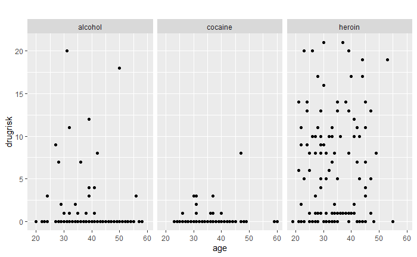

```r
ggplot(data = HELPrct, aes(x = age, y = drugrisk)) + geom_point()  + facet_wrap(~substance, ncol = 4) + labs(title = "")
```